# Smart Meter DFM Example

Alex Gibberd

2023-03-21

This document enables replication of the smart-meter application in [“The Sparse Dynamic Factor Model: A Regularised Quasi-Maximum Likelihood Approach”](https://arxiv.org), by Luke Mosley, Tak-Shing T. Chan and Alex Gibberd.

## Setup

For anonymity we provide the time-series of smart meter data labelled at the building type level. This is a subset of data collected over November 2020.

```r
setwd("C:/Users/alexa/Dropbox/Collab/SparseDFM")
devtools::load_all()
```

```
## ℹ Loading sparseDFM
```

```r
setwd("C:/Users/alexa/Dropbox/Collab/SparseDFM_SAC/code")

source("functions.R")
load("data.RData")
library(sparseDFM)
library(BigVAR)
```

## Estimation

We will first do some exploratory analysis to determine an appropriate size of model.

```r
# sparseDFM can use time-series objects to plot relevant xaxis
dayobs = 144 # observations/day
data.anon.ts = ts(data.anon, start=0, frequency=dayobs)
```

The below replicates Figure 5. in the paper

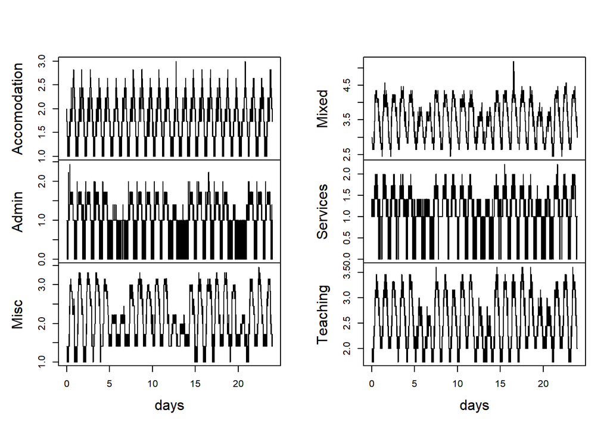

```r
series = c(1,16,19,28,31,33)
plot(data.anon.ts[,series], xlab="days", ylab=colnames(data.anon)[series],main="")
```

We now use the Information Criteria of Bai to suggest a number of factors to use.

```r
tuneFactors(data.anon.ts,type=2)
```

```
## Data contains missing values: imputing data with fillNA()
```

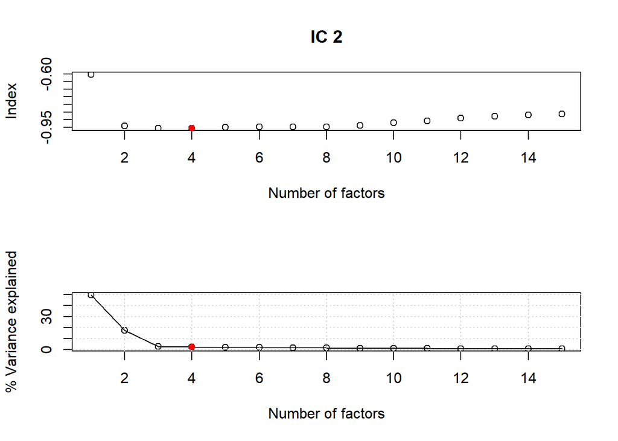

```
## [1] "The chosen number of factors using criteria type  2  is  4"
```

As presented in the paper, the criteria suggests to choose 4 factors. We proceed on this basis. Note, other IC criteria in Bai et al give simillar number of factors.

We compare the sparse DFM with a regular DFM ($\alpha=0$).

```r
# Estimate regular (exact) DFM
mod0 = sparseDFM(data.anon.ts, r=4, q = 0,
                alg = "EM",
                err = "IID",
                kalman = "univariate",
                store.parameters = TRUE,
                standardize = TRUE,
                max_iter = 100,
                threshold = 1e-04)
```

```r
# Estimate sparse DFM (across range of alphas)
mod = sparseDFM(data.anon.ts, r=4, q = 0,
                alphas = logspace(-3, -1, 100),
                alg = "EM-sparse",
                err = "IID",
                kalman = "univariate",
                store.parameters = TRUE,
                standardize = TRUE,
                max_iter = 100,
                threshold = 1e-04)
```

## Interpretation

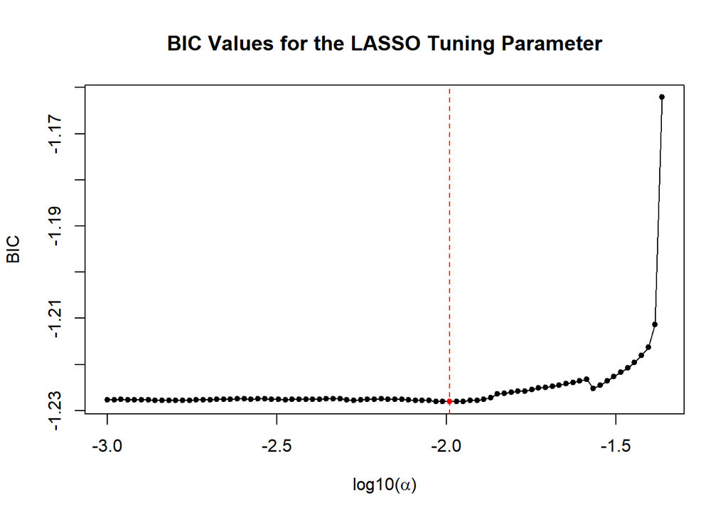

```r
# Plot the BIC values for each alpha
plot(mod, type = 'lasso.bic')
```

```r
# The best alpha chosen
mod$em$alpha_opt
```

```
## [1] 0.01023531
```

```r
optidx = which(mod$em$alpha_grid==mod$em$alpha_opt)

# Below is where the second dip appears in BIC curve
optidx2 = optidx + 21
```

*Note: The examples below are based on optidx2, however, there is not much difference in the lambda structure in this application, i.e. as a function of alpha. For other examples where the structure varies more considerably see Mosley et al 2023.*

A comparison of the loadings can be seen below.

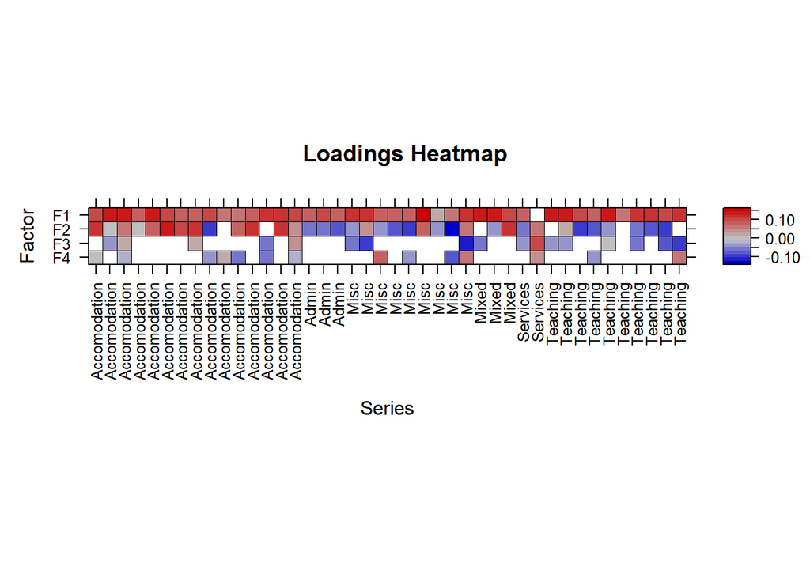

```r
plot(mod, type = 'loading.heatmap', use.series.names = TRUE, alpha_index=optidx2)
```

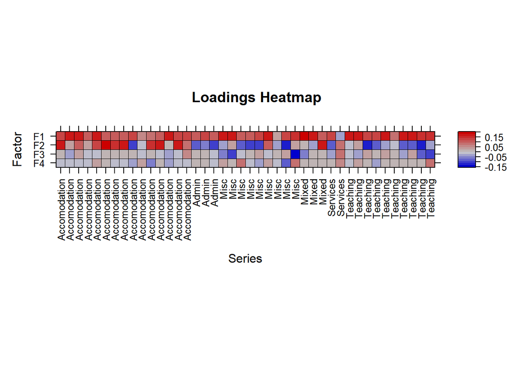

```r
plot(mod0, type = 'loading.heatmap', use.series.names = TRUE)
```

We can also visualise the estimated factors, e.g. based on the expectation step of our EM algorithm. First for the sparse DFM, then for the regular DFM.

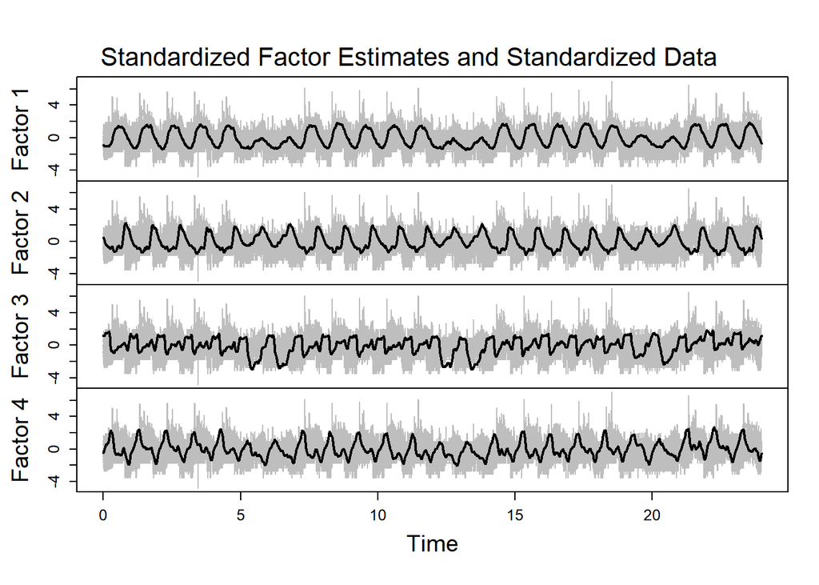

```r
plot(mod, type = 'factor', alpha_index=optidx2)
```

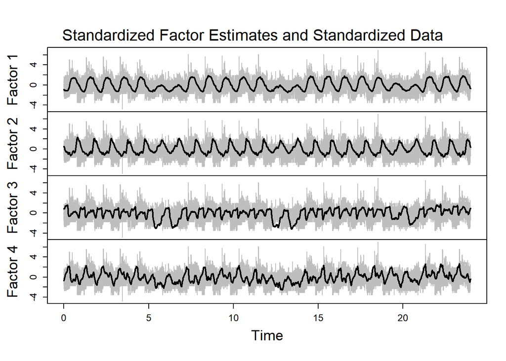

```r
plot(mod0, type = 'factor')
```

## Forecasting

The code below replicates the 1 hour ahead forecast examples found in the paper. You can also assess the forecasts for other buildings if desired.

```r
# Steps ahead (each step is 10 minutes)
h = 6
ntest = dim(data_test.anon)[1]
# sparse DFM Forecast
forecast1 = stepForecast(mod,data.anon,data_test.anon,h)
# AR(1) Forecast
forecast2 = arimaForecast(data.anon,data_test.anon,p=1,q=0,h)
```

For the SVAR forecast, it may be useful to use the pre-calculate optimal lambda rather than running the `BigVar` cross-validation scheme, which takes considerable time.

```r
## TAKES A LONG TIME TO RUN, CAN USE PRECALCULATED LAMBDA
lambdaGridSVAR = sparseDFM::logspace(-1,1.3,20)

svar.mod <- constructModel(as.matrix(fillNA2(data.anon)),
                           p=1,"Basic",gran=lambdaGridSVAR,
                           h=1,
                           cv="Rolling",
                           verbose=FALSE,
                           ownlambdas = TRUE,
                           IC=TRUE,
                           model.controls=list(intercept=TRUE))

results = cv.BigVAR(svar.mod)
lambdaopt = results@OptimalLambda
```

```r
# Below derived from cv on training data.
lambdaopt = 1.62377
```

```r
forecast3 = svarForecast(lambdaopt,data.anon,data_test.anon, h)
```

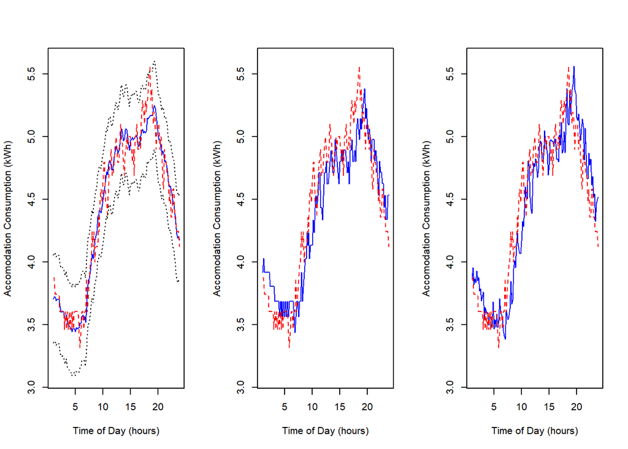

```r
# For the specific example in the paper we use
# the following  buidling
id = 5


len = (ntest-h)
mu = forecast1$Xhat[1:len,id]
true = data_test.anon[(h+1):ntest,id]
cl = mu[1:len]-1.96*sqrt(forecast1$XCov[1:len,id,id])
cu = mu[1:len]+1.96*sqrt(forecast1$XCov[1:len,id,id])
building = "Accomodation"
xt = seq((h/6),24-(1/6),1/6)
par(mfrow=c(1,3))

# Plot DFM Forecast

plot(xt, mu, lty=1, col="blue", type="l",
     ylim=c(min(cl),max(cu)),
     ylab=paste(building,"Consumption (kWh)"),
     xlab="Time of Day (hours)")
lines(xt, true, lty=2, col="red")
lines(xt, cl, lty=3)
lines(xt, cu, lty=3)


# Plot AR Forecast

mu2 = forecast2[1:len,id]
plot(xt, mu2, lty=1, col="blue", type="l",
     ylim=c(min(cl),max(cu)),
     ylab=paste(building,"Consumption (kWh)"),
     xlab="Time of Day (hours)")
lines(xt, true, lty=2, col="red")

# Plot SVAR Forecast

mu3 = forecast3[1:len,id]
plot(xt, mu3, lty=1, col="blue", type="l",
     ylim=c(min(cl),max(cu)),
     ylab=paste(building,"Consumption (kWh)"),
     xlab="Time of Day (hours)")
lines(xt, true, lty=2, col="red")
```

We can now evaluate the forecast performance over one (weekday) of data.

```r
type="MAPE"
errorDFM = evalForecast(forecast1$Xhat[1:len,],data_test.anon[(h+1):ntest,],type)
errorAR = evalForecast(forecast2[1:len,],data_test.anon[(h+1):ntest,],type)
errorSVAR = evalForecast(forecast3[1:len,],data_test.anon[(h+1):ntest,],type)
```

```r
# Find winner for each series
winner = apply(cbind(errorDFM,errorAR,errorSVAR),1,which.min)
cols = c("blue","red","navy")
```

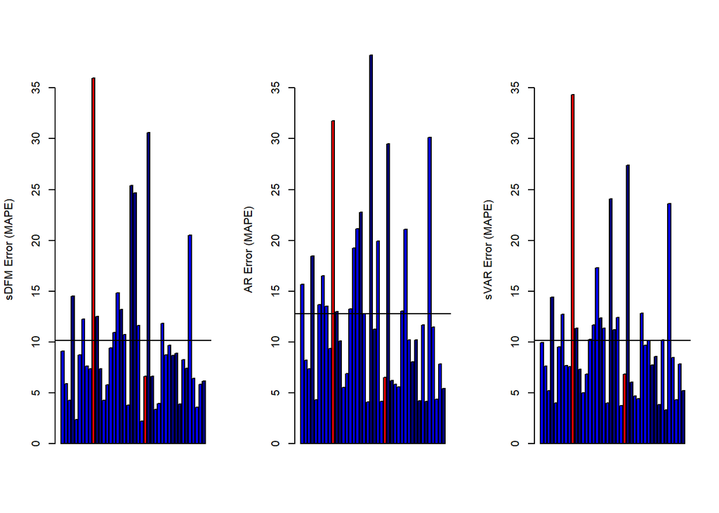

```r
par(mfrow=c(1,3))
maxerr = round(max(c(errorDFM,errorAR,errorSVAR)),1)
barplot(errorDFM, col=cols[winner], ylab=paste0("sDFM Error (",type,")"),ylim=c(0,maxerr) )
abline(h=mean(errorDFM))
barplot(errorAR,col=cols[winner], ylab=paste0("AR Error (",type,")"),ylim=c(0,maxerr))
abline(h=mean(errorAR))
barplot(errorSVAR,col=cols[winner], ylab=paste0("sVAR Error (",type,")"),ylim=c(0,maxerr))
abline(h=mean(errorSVAR))
```

## Further Details

For further examples and experiments please see the vignettes within the `sparseDFM` R package, available via CRAN or via [Github](https://github.com/mosleyl/sparseDFM).